# Homework 5

PSTAT 131/231

```r
library(janitor)
library(dbplyr)
library(tidyverse)
library(tidymodels)
library(ggplot2)
library(corrr)
library(ISLR)
library(ISLR2)
library(poissonreg)
library(discrim)

library(glmnet)
library(klaR)
library(pROC)
```

### Exercise 1

Install and load the `janitor` package. Use its `clean_names()` function on the Pokémon data, and save the results to work with for the rest of the assignment. What happened to the data? Why do you think `clean_names()` is useful?

```r
pokemon_no <- read.csv("pokemon.csv")
pokemon <- clean_names(pokemon_no)

head(pokemon)
```

```
##   x                  name type_1 type_2 total hp attack defense sp_atk sp_def
## 1 1             Bulbasaur  Grass Poison   318 45     49      49     65     65
## 2 2               Ivysaur  Grass Poison   405 60     62      63     80     80
## 3 3              Venusaur  Grass Poison   525 80     82      83    100    100
## 4 3 VenusaurMega Venusaur  Grass Poison   625 80    100     123    122    120
## 5 4            Charmander   Fire          309 39     52      43     60     50
## 6 5            Charmeleon   Fire          405 58     64      58     80     65
##   speed generation legendary
## 1    45          1     False
## 2    60          1     False
## 3    80          1     False
## 4    80          1     False
## 5    65          1     False
## 6    80          1     False
```

clean_name is useful because it cleans names of an object

### Exercise 2

Using the entire data set, create a bar chart of the outcome variable, `type_1`.

How many classes of the outcome are there? Are there any Pokémon types with very few Pokémon? If so, which ones?

For this assignment, we’ll handle the rarer classes by simply filtering them out. Filter the entire data set to contain only Pokémon whose `type_1` is Bug, Fire, Grass, Normal, Water, or Psychic.

After filtering, convert `type_1` and `legendary` to factors.

There are 800 outconmes total, and flying type has only few pokemon, which is less than 15.

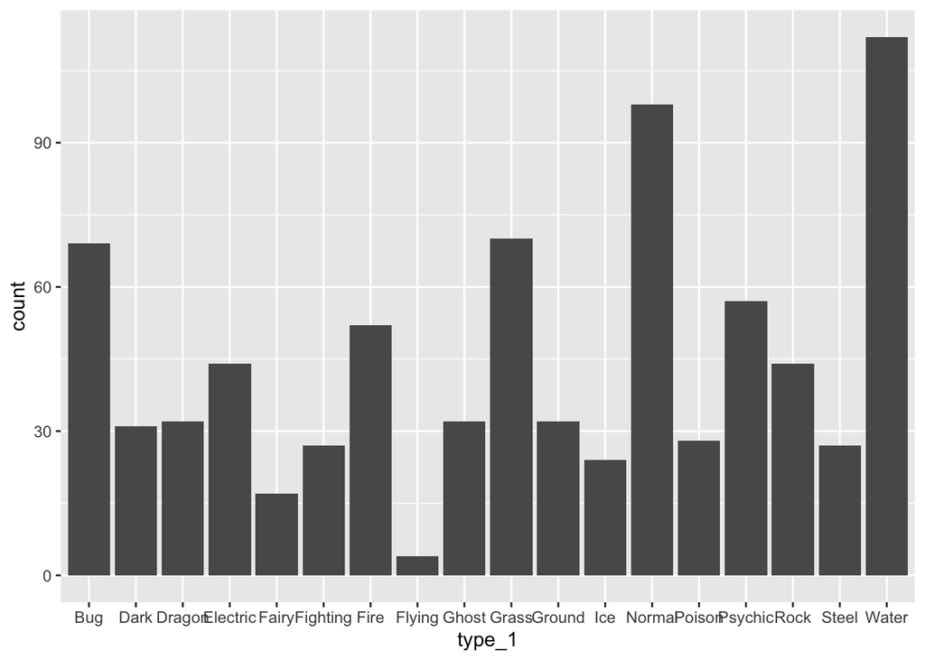

```r
ggplot(data=pokemon, aes(type_1)) + geom_bar()
```

```r
pokemon_1 <- pokemon %>% filter(type_1 %in% c("Bug","Fire","Grass","Normal","Water","Psychic"))

pokemon_1$type_1 <- factor(pokemon_1$type_1)
pokemon_1$legendary <- factor(pokemon_1$legendary)
```

### Exercise 3

Perform an initial split of the data. Stratify by the outcome variable. You can choose a proportion to use. Verify that your training and test sets have the desired number of observations.

Next, use *v*-fold cross-validation on the training set. Use 5 folds. Stratify the folds by `type_1` as well. *Hint: Look for a `strata` argument.* Why might stratifying the folds be useful?

stratifying the folds might be useful because it provides train/test indexes to split data in train/test sets.

```r
pokemon_1_split <- initial_split(pokemon_1, prop=0.8, strata = type_1)
pokemon_1_training <- training(pokemon_1_split)
pokemon_1_testing <- testing(pokemon_1_split)
dim(pokemon_1_training)
```

```
## [1] 364  13
```

```r
dim(pokemon_1_testing)
```

```
## [1] 94 13
```

```r
pokemon_fold <- vfold_cv(pokemon_1_training, v=5, strata=type_1)
pokemon_fold
```

```
## #  5-fold cross-validation using stratification
## # A tibble: 5 × 2
##   splits           id
##   <list>           <chr>
## 1 <split [289/75]> Fold1
## 2 <split [291/73]> Fold2
## 3 <split [291/73]> Fold3
## 4 <split [292/72]> Fold4
## 5 <split [293/71]> Fold5
```

### Exercise 4

Set up a recipe to predict `type_1` with `legendary`, `generation`, `sp_atk`, `attack`, `speed`, `defense`, `hp`, and `sp_def`.

- Dummy-code `legendary` and `generation`;
- Center and scale all predictors.

```r
pokemon_recipe <- recipe(type_1~legendary+generation+sp_atk+attack+speed+defense+hp+sp_def, data=pokemon_1_training) %>% step_dummy(all_nominal_predictors()) %>% step_normalize(all_predictors())

pokemon_recipe %>% prep() %>% bake(pokemon_1_training)
```

```
## # A tibble: 364 × 9
##    generation sp_atk attack   speed defense     hp sp_def type_1 legendary_True
##         <dbl>  <dbl>  <dbl>   <dbl>   <dbl>  <dbl>  <dbl> <fct>           <dbl>
##  1      -1.32 -1.63  -1.40  -0.822   -1.20  -0.918 -1.81  Bug            -0.271
##  2      -1.32 -1.47  -1.71  -1.33    -0.496 -0.737 -1.63  Bug            -0.271
##  3      -1.32  0.506 -0.946  0.0224  -0.672 -0.375  0.304 Bug            -0.271
##  4      -1.32 -1.63  -1.25  -0.653   -1.38  -1.10  -1.81  Bug            -0.271
##  5      -1.32 -1.47  -1.56  -1.16    -0.672 -0.918 -1.63  Bug            -0.271
##  6      -1.32 -0.865  0.427  0.191   -1.03  -0.193  0.304 Bug            -0.271
##  7      -1.32 -1.78   2.26   2.56    -1.03  -0.193  0.304 Bug            -0.271
##  8      -1.32 -0.865 -0.183 -1.50    -0.496 -1.28  -0.577 Bug            -0.271
##  9      -1.32 -0.408  0.580 -1.33     0.388 -0.375  0.304 Bug            -0.271
## 10      -1.32 -1.02  -0.640 -0.822   -0.672 -0.375 -0.577 Bug            -0.271
## # … with 354 more rows
```

### Exercise 5

We’ll be fitting and tuning an elastic net, tuning `penalty` and `mixture` (use `multinom_reg` with the `glmnet` engine).

Set up this model and workflow. Create a regular grid for `penalty` and `mixture` with 10 levels each; `mixture` should range from 0 to 1. For this assignment, we’ll let `penalty` range from -5 to 5 (it’s log-scaled).

How many total models will you be fitting when you fit these models to your folded data?

there are 500 models total in my folded data

```r
tune_engine <- multinom_reg(penalty = tune(), mixture = tune()) %>%
  set_mode("classification") %>%
  set_engine("glmnet")

pokemon_workflow <- workflow() %>%
  add_recipe(pokemon_recipe) %>%
  add_model(tune_engine)

penalty_grid <- grid_regular(penalty(range = c(-5, 5)), mixture(range=c(0,1)), levels = 10)
```

### Exercise 6

Fit the models to your folded data using `tune_grid()`.

Use `autoplot()` on the results. What do you notice? Do larger or smaller values of `penalty` and `mixture` produce better accuracy and ROC AUC?

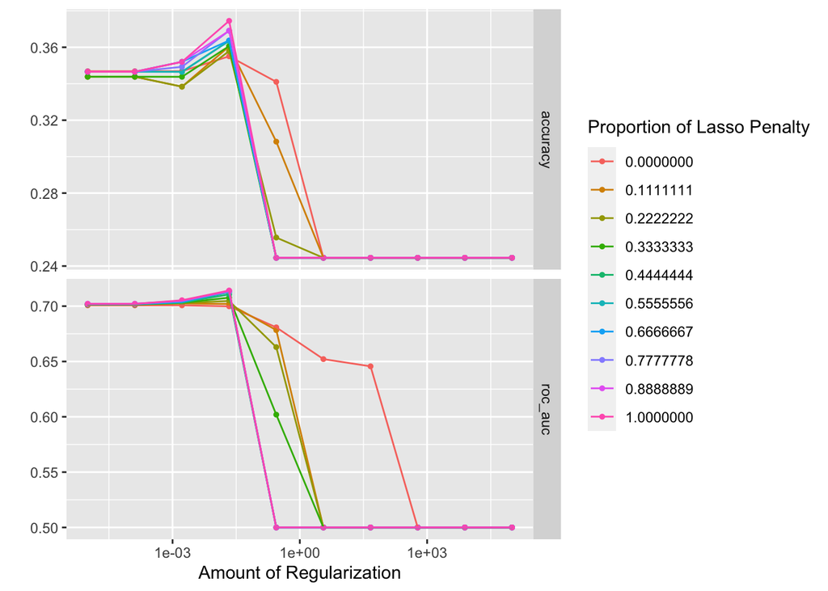

```r
tune_res <- tune_grid(
  pokemon_workflow,
  resamples = pokemon_fold,
  grid = penalty_grid
)

autoplot(tune_res)
```

### Exercise 7

Use `select_best()` to choose the model that has the optimal `roc_auc`. Then use `finalize_workflow()`, `fit()`, and `augment()` to fit the model to the training set and evaluate its performance on the testing set.

```r
best_penalty <- select_best(tune_res, metric="roc_auc")
final <- finalize_workflow(pokemon_workflow, best_penalty)

final_fit <- fit(final, data = pokemon_1_training)
predict(final_fit, new_data=pokemon_1_testing, type="class")
```

```
## # A tibble: 94 × 1
##    .pred_class
##    <fct>
##  1 Water
##  2 Water
##  3 Bug
##  4 Normal
##  5 Water
##  6 Normal
##  7 Water
##  8 Water
##  9 Water
## 10 Normal
## # … with 84 more rows
```

```r
test_acc <- augment(final_fit, new_data = pokemon_1_testing) %>%
  accuracy(truth = type_1, estimate = .pred_class)

test_acc
```

```
## # A tibble: 1 × 3
##   .metric  .estimator .estimate
##   <chr>    <chr>          <dbl>
## 1 accuracy multiclass     0.394
```

### Exercise 8

Calculate the overall ROC AUC on the testing set.

Then create plots of the different ROC curves, one per level of the outcome. Also make a heat map of the confusion matrix.

What do you notice? How did your model do? Which Pokemon types is the model best at predicting, and which is it worst at? Do you have any ideas why this might be?

Normal type is the best at predicting, and psychic is the worst.

```r
augment(final_fit, new_data = pokemon_1_testing) %>%
  roc_auc(type_1, .pred_Bug, .pred_Fire, .pred_Grass, .pred_Normal, .pred_Water, .pred_Psychic)
```

```
## # A tibble: 1 × 3
##   .metric .estimator .estimate
##   <chr>   <chr>          <dbl>
## 1 roc_auc hand_till      0.647
```

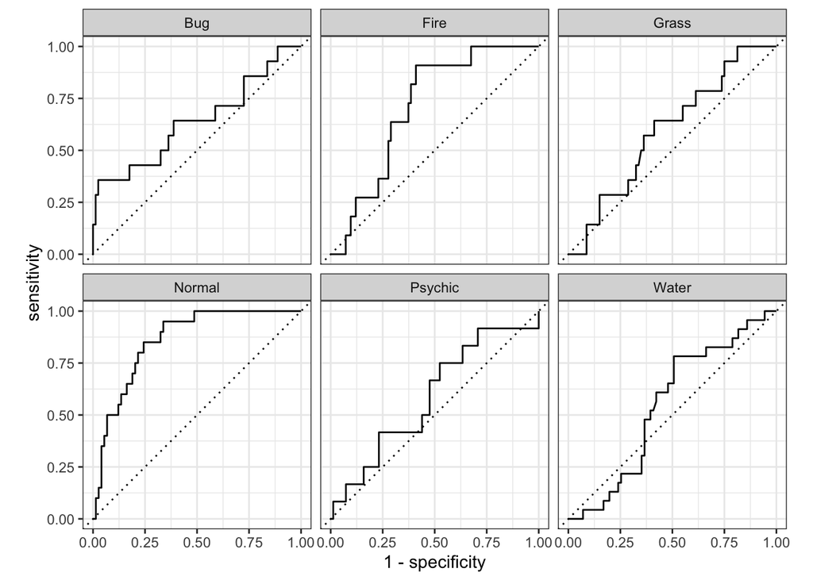

```r
augment(final_fit, new_data=pokemon_1_testing) %>% roc_curve(type_1, .pred_Bug, .pred_Fire, .pred_Grass, .pred_Normal, .pred_Water, .pred_Psychic) %>%
  autoplot()
```